# Weight_problems

Fay

2024-04-24

How many mice went through primary infections?

```r
Challenge %>%
           filter(infection == "primary", Mouse_ID %in% lab$Mouse_ID,
                  dpi == max_dpi) %>%
    summarise(n())
```

```
##   n()
## 1 136
```

How many mice died in the primary infections?

```r
Challenge %>%
           filter(infection == "primary", Mouse_ID %in% lab$Mouse_ID,
                  death == "primary", dpi == max_dpi) %>%
    summarise(n())
```

```
##   n()
## 1  20
```

How many mice were in the challenge infections?

```r
Challenge %>%
           filter(infection == "challenge", Mouse_ID %in% lab$Mouse_ID,
                  dpi == max_dpi, death == "challenge") %>%
    summarise(n())
```

```
##   n()
## 1 148
```

Something is fishy here. Do we have duplicates? Yes, I forgot to remove the spleen measurements. Luke used the spleen for gene expression for some mice. We use here the mesenterial lymphnodes. (?)

```r
Challenge %>%
           filter(infection == "challenge", Mouse_ID %in% lab$Mouse_ID,
                  dpi == max_dpi, death == "challenge", Position == "mLN") %>%
    summarize(n())
```

```
##   n()
## 1 116
```

Original in article of primary infections: I include mice that died in primary infections, but also the mice that went on to be challenged.

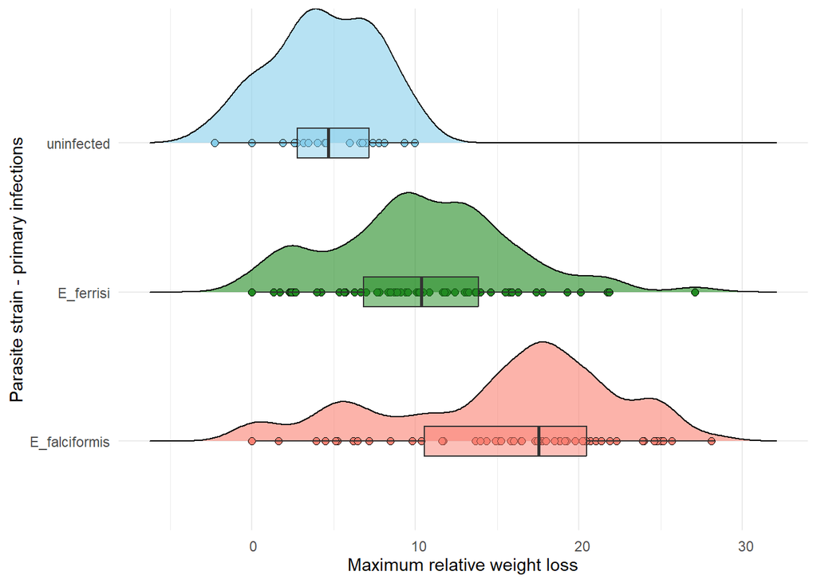

```r
ggplot(Challenge %>%
           filter(infection == "primary", Mouse_ID %in% lab$Mouse_ID) %>%
           group_by(Mouse_ID),
       aes(x = WL_max, y = Parasite_primary, fill = Parasite_primary)) +
    geom_density_ridges(jittered_points = TRUE,
                        position = position_points_jitter(height = 0),
                        scale = 0.9, alpha = 0.6, point_shape = 21,
                        point_size = 2, point_alpha = 1) +
    geom_boxplot(width = 0.2, outlier.shape = NA, alpha = 0.5,
                 position = position_nudge(x = 0.2)) +
    # coord_flip() +
    theme_minimal() +
    scale_fill_manual(values = color_mapping) +
    theme(legend.position = "none",
          axis.text.x = element_text(angle = 0, vjust = 0.5, hjust=0.3)) +
    xlab("Maximum relative weight loss") +
    ylab("Parasite strain - primary infections")
```

What happens, if I remove the mice that were challenged. Here, including just the mice that died in the primary infections.

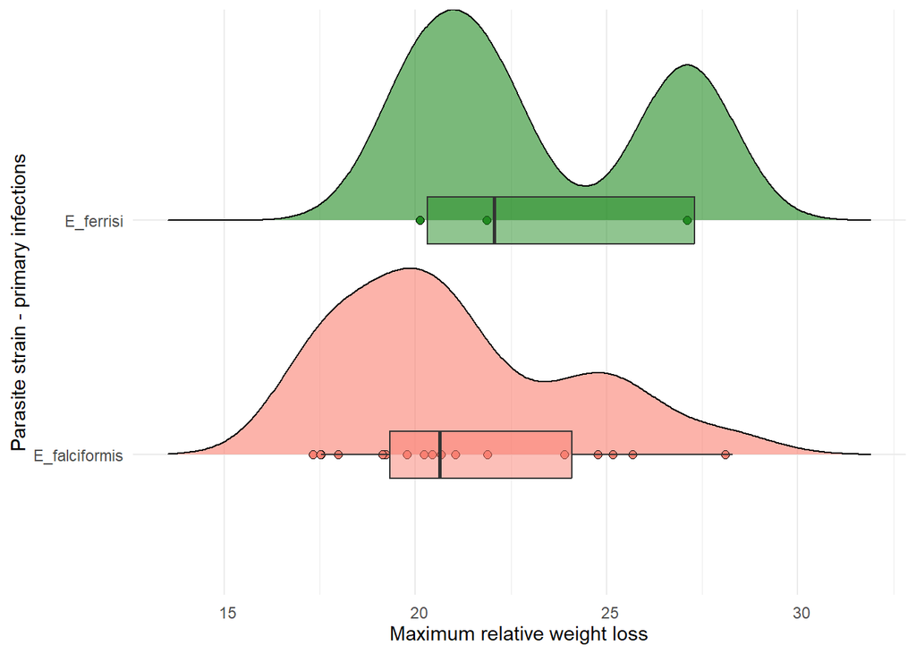

```r
ggplot(Challenge %>%
           filter(infection == "primary", Mouse_ID %in% lab$Mouse_ID,
                  death == "primary") %>%
           group_by(Mouse_ID),
       aes(x = WL_max, y = Parasite_primary, fill = Parasite_primary)) +
    geom_density_ridges(jittered_points = TRUE,
                        position = position_points_jitter(height = 0),
                        scale = 0.9, alpha = 0.6, point_shape = 21,
                        point_size = 2, point_alpha = 1) +
    geom_boxplot(width = 0.2, outlier.shape = NA, alpha = 0.5,
                 position = position_nudge(x = 0.2)) +
    # coord_flip() +
    theme_minimal() +
    scale_fill_manual(values = color_mapping) +
    theme(legend.position = "none",
          axis.text.x = element_text(angle = 0, vjust = 0.5, hjust=0.3)) +
    xlab("Maximum relative weight loss") +
    ylab("Parasite strain - primary infections")
```

Where are the uninfected mice? Did we just have infected mice? I remember reaching the same conclusion before.

How many mice died on each day in the primary infections?

```r
Challenge %>%
           filter(infection == "primary", Mouse_ID %in% lab$Mouse_ID,
                  death == "primary", dpi == max_dpi) %>%
    group_by(max_dpi) %>%
    summarise(n())
```

```
## # A tibble: 6 × 2
##   max_dpi `n()`
##     <int> <int>
## 1       5     2
## 2       6     1
## 3       8     6
## 4       9     6
## 5      10     3
## 6      11     2
```

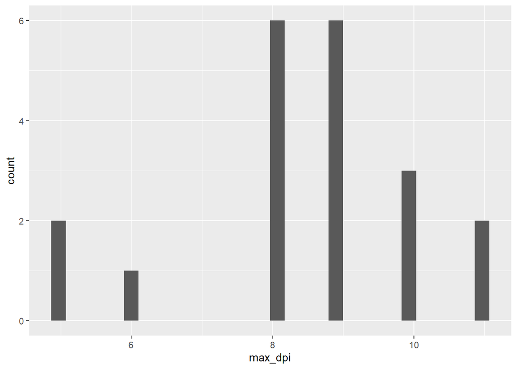

```r
Challenge %>%
           filter(infection == "primary", Mouse_ID %in% lab$Mouse_ID,
                  death == "primary", dpi == max_dpi) %>%
    ggplot(aes(x = max_dpi)) +
    geom_histogram()
```

What about the challenge infections? How many mice died on each day in the primary infections?

```r
Challenge %>%
           filter(infection == "challenge", Mouse_ID %in% lab$Mouse_ID,
                  death == "challenge", dpi == max_dpi, Position == "mLN") %>%
    group_by(max_dpi) %>%
    summarise(n())
```

```
## # A tibble: 5 × 2
##   max_dpi `n()`
##     <int> <int>
## 1       2     1
## 2       5     1
## 3       6     2
## 4       7     1
## 5       8   111
```

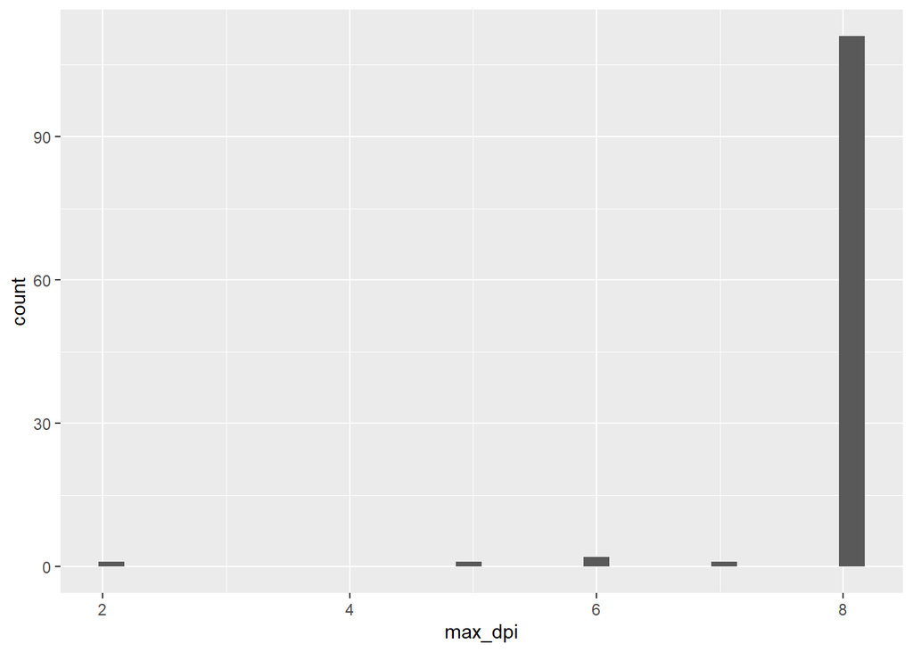

```r
Challenge %>%
           filter(infection == "challenge", Mouse_ID %in% lab$Mouse_ID,
                  death == "challenge", dpi == max_dpi, Position == "mLN") %>%
    ggplot(aes(x = max_dpi)) +
    geom_histogram()
```

# Challenge infections remains the same

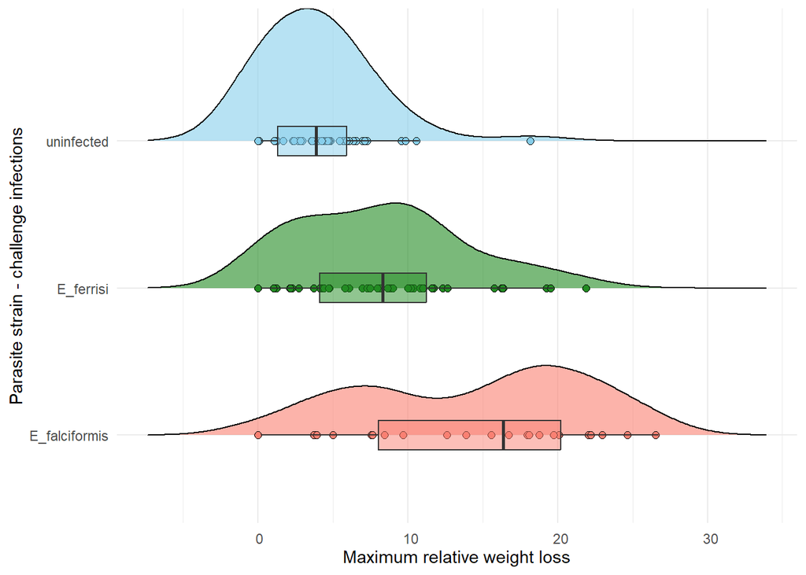

```r
ggplot(lab %>%
           filter(infection == "challenge") %>%
           group_by(Mouse_ID),
       aes(x = WL_max, y = Parasite_challenge, fill = Parasite_challenge)) +
    geom_density_ridges(jittered_points = TRUE, position =
                            position_points_jitter(height = 0),
                        scale = 0.9, alpha = 0.6, point_shape = 21,
                        point_size = 2, point_alpha = 1) +
    geom_boxplot(width = 0.2, outlier.shape = NA, alpha = 0.5,
                 position = position_nudge(x = 0.2)) +
    # coord_flip() +
    theme_minimal() +
    scale_fill_manual(values = color_mapping) +
    theme(legend.position = "none",
          axis.text.x = element_text(angle = 0, vjust = 0.5, hjust=0.3)) +
    xlab("Maximum relative weight loss") +
    ylab("Parasite strain - challenge infections")
```

So what about the weight loss per dpi. Here is what I originally plotted:

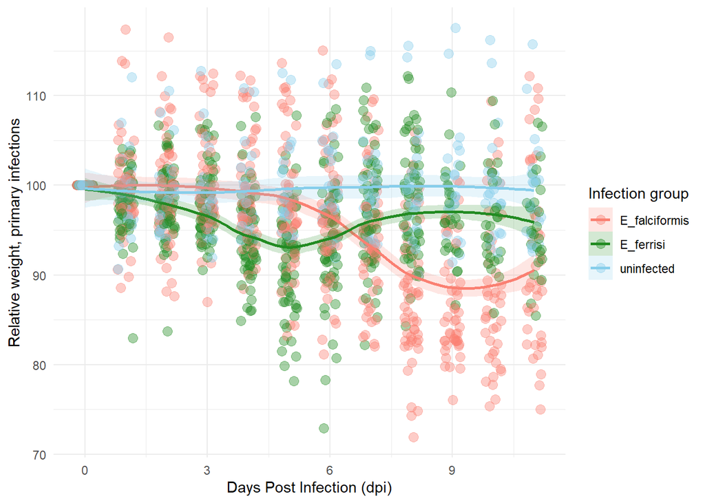

```r
#relative weight loss per day - primary
Challenge %>%
    filter(infection == "primary", Mouse_ID %in% lab$Mouse_ID) %>%
    ggplot(aes(x = dpi, y = relative_weight, color = Parasite_primary,
               fill = Parasite_primary)) +
    geom_jitter(width = 0.2, height = 0, alpha = 0.4,
                shape = 21, stroke = 0.5, size = 3) + # Adjusted for outlines
    geom_smooth(aes(fill = Parasite_primary),
                method = "loess", se = TRUE, alpha = 0.2) +
    # Add smooth line with confidence intervals
    scale_color_manual(values = color_mapping) + # Apply custom color mapping
    scale_fill_manual(values = color_mapping) +
    # Ensure fills match colors for confidence intervals
    labs(#title = "Relative Weight by Days Post Infection",
        x = "Days Post Infection (dpi)",
        y = "Relative weight, primary infections",
        color = "Infection group",
        fill = "Infection group") + # Added for consistency with the legend
    theme_minimal() + # Use a minimal theme for a cleaner look
    theme(legend.position = "right", # Adjust legend position
          plot.title = element_text(hjust = 0.5), # Center the plot title
          legend.title.align = 0.5)
```

Should I include ONLY the 20 mice that were solely subjected to primary infections?

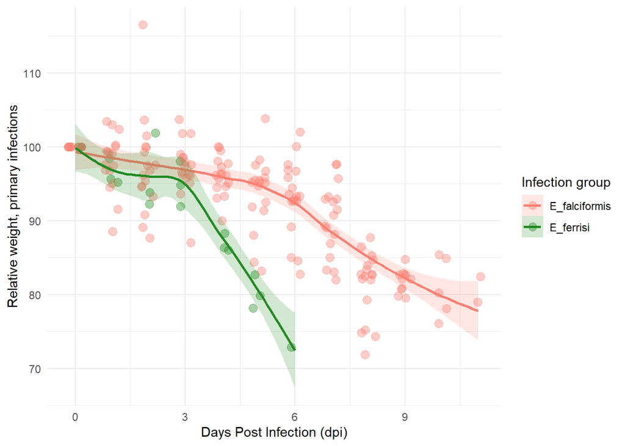

```r
#relative weight loss per day - primary
Challenge %>%
    filter(infection == "primary", Mouse_ID %in% lab$Mouse_ID, death == "primary") %>%
    ggplot(aes(x = dpi, y = relative_weight, color = Parasite_primary,
               fill = Parasite_primary)) +
    geom_jitter(width = 0.2, height = 0, alpha = 0.4,
                shape = 21, stroke = 0.5, size = 3) + # Adjusted for outlines
    geom_smooth(aes(fill = Parasite_primary),
                method = "loess", se = TRUE, alpha = 0.2) +
    # Add smooth line with confidence intervals
    scale_color_manual(values = color_mapping) + # Apply custom color mapping
    scale_fill_manual(values = color_mapping) +
    # Ensure fills match colors for confidence intervals
    labs(#title = "Relative Weight by Days Post Infection",
        x = "Days Post Infection (dpi)",
        y = "Relative weight, primary infections",
        color = "Infection group",
        fill = "Infection group") + # Added for consistency with the legend
    theme_minimal() + # Use a minimal theme for a cleaner look
    theme(legend.position = "right", # Adjust legend position
          plot.title = element_text(hjust = 0.5), # Center the plot title
          legend.title.align = 0.5)
```

Why do the ferrisi mice loose more weight? They probably died on day 6 naturally? Many mice fall under the 80% relative weight.

Back to the challenge infections:

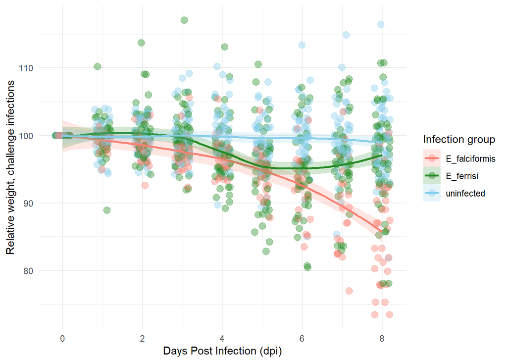

```r
#relative weight loss per day - challenge
Challenge %>%
    filter(infection == "challenge", Mouse_ID %in% lab$Mouse_ID) %>%
    ggplot(aes(x = dpi, y = relative_weight, color = Parasite_challenge,
               fill = Parasite_challenge)) +
    geom_jitter(width = 0.2, height = 0, alpha = 0.4,
                shape = 21, stroke = 0.5, size = 3) + # Adjusted for outlines
    geom_smooth(aes(fill = Parasite_challenge),
                method = "loess", se = TRUE, alpha = 0.2) +
    #Add smooth line with confidence intervals
    scale_color_manual(values = color_mapping) + # Apply custom color mapping
    scale_fill_manual(values = color_mapping) +
    # Ensure fills match colors for confidence intervals
    labs(#title = "Relative Weight by Days Post Infection",
        x = "Days Post Infection (dpi)",
        y = "Relative weight, challenge infections",
        color = "Infection group",
        fill = "Infection group") + # Added for consistency with the legend
    theme_minimal() + # Use a minimal theme for a cleaner look
    theme(legend.position = "right", # Adjust legend position
          plot.title = element_text(hjust = 0.5), # Center the plot title
          legend.title.align = 0.5)
```

Mouse strains:

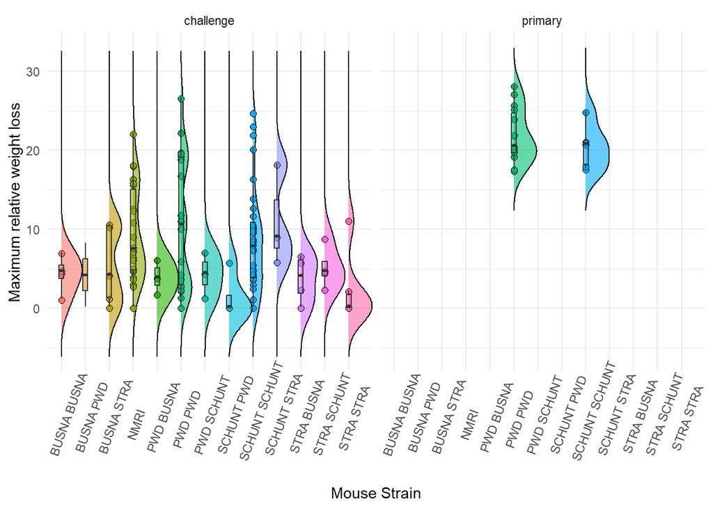

```r
# transform mouse strain into factor
lab$mouse_strain <- as.factor(lab$mouse_strain)

lab$mouse_strain <- gsub(pattern = "_", " ", lab$mouse_strain)

#Numbers of each mouse strain
ggplot(lab, aes(x = WL_max, y = mouse_strain, fill = mouse_strain)) +
    geom_density_ridges(jittered_points = TRUE, position =
                            position_points_jitter(height = 0),
                        scale = 0.9, alpha = 0.6, point_shape = 21,
                        point_size = 2, point_alpha = 1) +
    geom_boxplot(width = 0.2, outlier.shape = NA, alpha = 0.5,
                 position = position_nudge(x = 0.2)) +
    coord_flip() +
    theme_minimal() +
    theme(legend.position = "none",
          axis.text.x = element_text(angle = 70, vjust = 0.5, hjust=0.3)) +
    xlab("Maximum relative weight loss") +
    ylab("Mouse Strain") +
    facet_grid(~infection)
```